# Modeling and prediction for movies

## Setup

### Load packages

```r
library(ggplot2)
library(dplyr)
library(statsr)
```

### Load data

```r
load("movies.Rdata")
```

## Part 1: Data

The movies data is a sample size of 651 movies released prior to 2016 which were selected randomly. The sample movies are observational and use random sampling and therefore the results are not causal, but are generalizable to the larger population of movies.

My only concern is that there might be some independence issues if movies are from the same studio. That might need to be taken into account in an analysis.

## Part 2: Research question

**Is there a relationship between the runtime of a mainstream movie and the audience rating?**  
The regression analysis below will initially focus on how movie runtime relates to audience rating. Then we will create a Multiple Regression model by adding the MPAA rating to the model and noting the effect.

Lastly, we will do a second Multiple Regression analysis with a new variable and attempt to predict the score of a 2016 movie.

I’m interested to find out if there is some type of predictive value in the length of a movie on it’s popularity.

## Part 3: Exploratory data analysis

### Data Preparation

**The following code** creates a new data frame of the needed variables for the analysis. It also removes movies that are rated NC-17 or Unrated and also only includes movies with a runtime between 80 and 150 minutes. This is done to focus on movies that would be considered more mainstream theater movies.

It also creates a new variable called `oscar_acting` which determines whether a movie has either a best actor or best actress Oscar winner. This new variable will also be used in later Multiple regression analysis.

```r
mainstream_mov <- movies %>%
  filter(mpaa_rating == "PG-13" | mpaa_rating == "R" | mpaa_rating == "PG") %>%
  filter(title_type == "Feature Film") %>%
  filter(runtime > 80,runtime < 150) %>%
  mutate(oscar_acting = ifelse(best_actor_win == "yes", "yes",
                                ifelse(best_actress_win == "yes", "yes", "no"))) %>%
  select(runtime, audience_score, mpaa_rating, oscar_acting)
mainstream_mov$oscar_acting <- factor(mainstream_mov$oscar_acting)
head(mainstream_mov)
```

```
## # A tibble: 6 × 4
##   runtime audience_score mpaa_rating oscar_acting
##     <dbl>          <dbl>      <fctr>       <fctr>
## 1     101             81       PG-13           no
## 2      84             91           R           no
## 3     139             76          PG          yes
## 4      90             27           R           no
## 5     142             76       PG-13           no
## 6      93             47           R          yes
```

*The above output* is the first six lines of the new data frame

The summary belows displays Summary Statistics for the new data frame.

```r
summary(mainstream_mov)
```

```
##     runtime      audience_score   mpaa_rating  oscar_acting
##  Min.   : 81.0   Min.   :11.00   G      :  0   no :411
##  1st Qu.: 94.0   1st Qu.:44.00   NC-17  :  0   yes:128
##  Median :104.0   Median :61.00   PG     :106
##  Mean   :105.8   Mean   :59.57   PG-13  :126
##  3rd Qu.:115.5   3rd Qu.:76.00   R      :307
##  Max.   :149.0   Max.   :95.00   Unrated:  0
```

## Part 4: Modeling

### Linear Regression

*The scatterplot below* shows that there is a linear trend when evaluating the runtime of a movie vs the audience score.

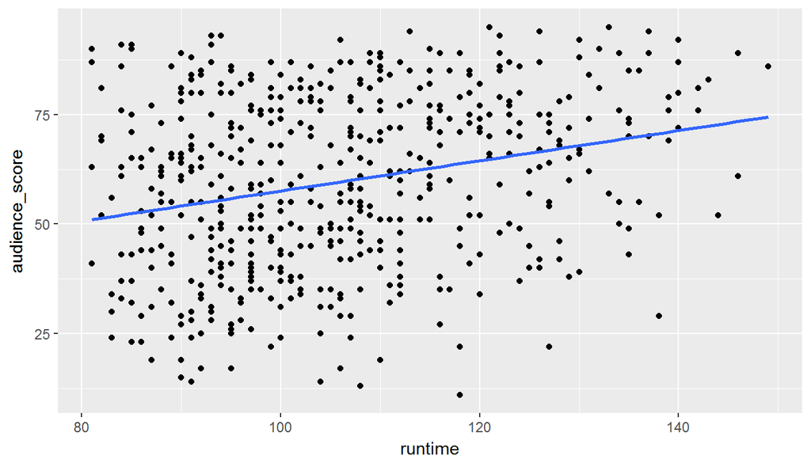

```r
### scatterplot audience score vs runtime
ggplot(data = mainstream_mov, aes(x = runtime, y = audience_score)) +
  geom_point() +
  stat_smooth(method = "lm", se = FALSE)
```

*The summary of the model* is shown below. The summary indicates that for each minute increase of runtime the audience score rises by about 1/3 of a point. However, the *R-sqaured value is .06* indicating that the correlation isn’t very strong.

```r
##model summary simple regression of audiencescore ~ runtime
s_score <- lm(audience_score~runtime, data = mainstream_mov)
summary(s_score)
```

```
##
## Call:
## lm(formula = audience_score ~ runtime, data = mainstream_mov)
##
## Residuals:
##     Min      1Q  Median      3Q     Max
## -52.776 -15.000   0.639  15.552  38.986
##
## Coefficients:
##             Estimate Std. Error t value Pr(>|t|)
## (Intercept) 23.07756    5.93955   3.885 0.000115 ***
## runtime      0.34490    0.05559   6.204  1.1e-09 ***
## ---
## Signif. codes:  0 '***' 0.001 '**' 0.01 '*' 0.05 '.' 0.1 ' ' 1
##
## Residual standard error: 19.18 on 537 degrees of freedom
## Multiple R-squared:  0.06688,    Adjusted R-squared:  0.06514
## F-statistic: 38.49 on 1 and 537 DF,  p-value: 1.101e-09
```

*The residuals plot below* is used to evaluate that the conditions are reasonable. This plot shows that the residuals are constant, not fan shaped, and nearly normal. Also, the movies are sampled randomly for independence.

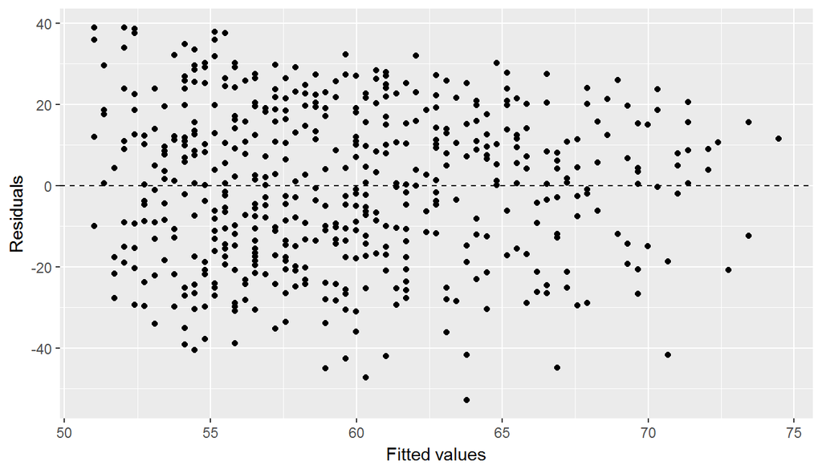

```r
## residuals plot of s_score
ggplot(data = s_score, aes(x = .fitted, y = .resid)) +
  geom_point() +
  geom_hline(yintercept = 0, linetype = "dashed") +
  xlab("Fitted values") +
  ylab("Residuals")
```

## Multiple Linear Regression #1

*The first multiple regression model* is used to determine if adding the mpaa_rating to the runtime model will have a relationship to the audience score.

*The boxplot below* is used to evaluate the variance of mpaa rating. From the boxplot it does seem that the PG-13 rated movies have a lower mean audience score and a little less variability. This may warrant future investigation.

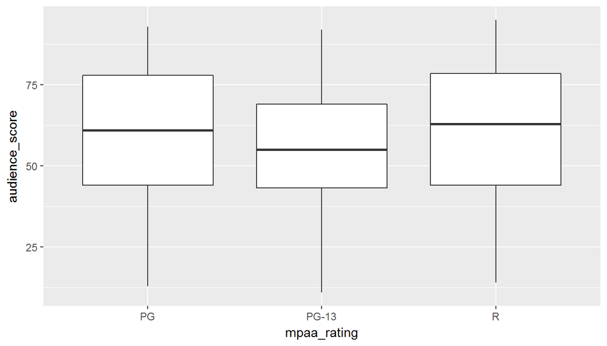

```r
##boxplot of mpaa rating vs audience score
ggplot(data = mainstream_mov, aes(x = mpaa_rating, y = audience_score)) +
  geom_boxplot()
```

*The summary of the new model below* shows that the MPAA rating of the movie brings the *adjusted R-squared value up to .08.*

```r
## multiple regression of runtime + mpaa_rating
m_score <- lm(audience_score~runtime + mpaa_rating, data = mainstream_mov)
summary(m_score)
```

```
##
## Call:
## lm(formula = audience_score ~ runtime + mpaa_rating, data = mainstream_mov)
##
## Residuals:
##     Min      1Q  Median      3Q     Max
## -49.005 -15.507   1.204  16.018  37.866
##
## Coefficients:
##                  Estimate Std. Error t value Pr(>|t|)
## (Intercept)      22.02861    5.98247   3.682 0.000255 ***
## runtime           0.37015    0.05558   6.660 6.82e-11 ***
## mpaa_ratingPG-13 -7.24050    2.52727  -2.865 0.004335 **
## mpaa_ratingR      0.12301    2.14424   0.057 0.954272
## ---
## Signif. codes:  0 '***' 0.001 '**' 0.01 '*' 0.05 '.' 0.1 ' ' 1
##
## Residual standard error: 18.97 on 535 degrees of freedom
## Multiple R-squared:  0.09104,    Adjusted R-squared:  0.08594
## F-statistic: 17.86 on 3 and 535 DF,  p-value: 4.627e-11
```

*The equation of the model is shown below*
$$\begin{aligned}
\widehat{score} &= \hat{\beta}_0 + \hat{\beta}_1 \times runtime + \hat{\beta}_2 \times (0\ or\ 1) \\\end{aligned}$$

## Multiple Linear Regression #2

*The second regression model* is used to determine if adding the the `oscar_acting` variable to the runtime model will have an effect on the audience score.

*The boxplot below* is used to evaluate the variance of the `oscar_acting` variable. From the boxplot it seems they are fairly consistent in their means and their variance.

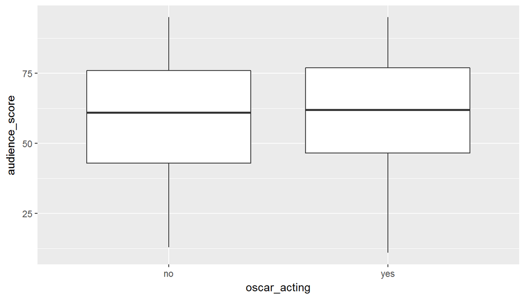

```r
##boxplot of mpaa rating vs audience score
ggplot(data = mainstream_mov, aes(x = oscar_acting, y = audience_score)) +
  geom_boxplot()
```

*The summary below* shows that the adding the `oscar_acting` variable into the model brings the *adjusted R-squared value back down to .06.*

```r
## multiple regression of runtime + mpaa_rating
m_score_oscar <- lm(audience_score~runtime + oscar_acting, data = mainstream_mov)
summary(m_score_oscar)
```

```
##
## Call:
## lm(formula = audience_score ~ runtime + oscar_acting, data = mainstream_mov)
##
## Residuals:
##     Min      1Q  Median      3Q     Max
## -51.876 -15.046   0.701  15.234  39.022
##
## Coefficients:
##                 Estimate Std. Error t value Pr(>|t|)
## (Intercept)      22.2360     6.0741   3.661 0.000276 ***
## runtime           0.3559     0.0580   6.136 1.64e-09 ***
## oscar_actingyes  -1.3559     2.0256  -0.669 0.503539
## ---
## Signif. codes:  0 '***' 0.001 '**' 0.01 '*' 0.05 '.' 0.1 ' ' 1
##
## Residual standard error: 19.19 on 536 degrees of freedom
## Multiple R-squared:  0.06766,    Adjusted R-squared:  0.06418
## F-statistic: 19.45 on 2 and 536 DF,  p-value: 7.015e-09
```

## Part 5: Prediction

Since the Adjusted R-squared value went up to .08, we will use the model that includes the `runtime` + `mpaa_rating` of the movie to predict the audience score of a 2016 movie.

The movie we will use is Deadpool. The runtime of the movie is 108 minutes and the MPAA rating is R. This information was gathered from the rotten tomatoes web site directly.

The code below creates the dataframe for deadpool:

```r
deadpool <- data.frame(runtime = 108, mpaa_rating = "R")
```

Next we create an audience score prediction for Deadpool

```r
round(predict(m_score, deadpool),0)
```

```
##  1
## 62
```

Last, we create a prediction interval for the score of Deadpool.

```r
round(predict(m_score, deadpool, interval = "prediction", level = 0.95),0)
```

```
##   fit lwr upr
## 1  62  25  99
```

## Part 6: Conclusion

The prediction for the score of Deadpool was 62 when in fact the real audience score is 90. This isn’t surprising since the adjusted R-Squared of the model was only .08. We didn’t expect these two variables to have a strong predictive value on the audience score.

It was however useful to note that when it comes to the runtime of a movie there is a linear relationship with the audience score.

It was also interesting to learn during the analysis that PG-13 movies have a lower average rating with everything else held constant.

*In future research*, it would be interesting to analyze the relationship between the audience score and runtime for PG-13 movies.